# Data Mining: Titanic(1)

```
PassengerId
Survived
Pclass
Name
Sex
Age
SibSp
Parch
Ticket
Fare
Cabin
Embarked
```

變數有以上12個，其中**Survived**是我們想預測的(也就是Y)， 在開始玩這筆資料之前，我想先暫時**不**去注意：

- Passenger
- Name
- Ticket
- Cabin

理由是“PassengerId”看起來好像沒那麼重要，其餘的都是有點難處理的狀態。

**Survived**是**0**代表**最後死亡**，反之**1**代表**最後存活**。

- 圓餅圖有點難把數字貼上去(我廢)。
- 死的人比較多QQ。

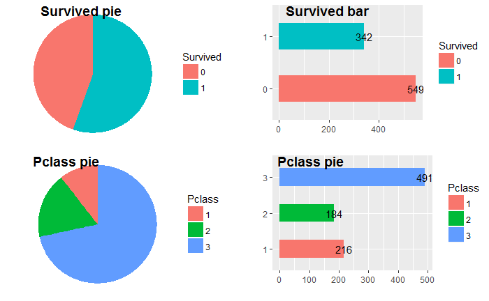

**Pclass**代表社會階級，其中**3**代表**低下階層**、**2**代表**中階階層** 以及**1**代表**上位階層**，這個類別變數的大小其實是有意義的。

- 船上最多的是**3**的階級。
- **2**反而是最少，**1**居然比**2**來的多一些。

**Sex**代表性別，男姓比女性多不少。

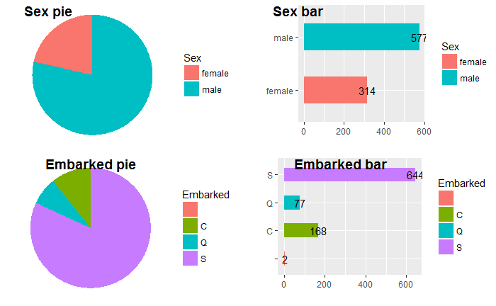

**Embarked**代表登船港口，**C**代表**瑟堡**、**Q**代表**皇后鎮**、**S**代表 **南安普頓**以及**有人登船港口不明**！

- 有2位不知道哪裡登船的人。
- 大多數人都來自**S**港口，其次是**C**港口，最後是**Q**港口。

#### 根據這筆資料簡單的summary：

- 死亡人數多餘存活。
- 船上人數最多的人是來自低下階層。
- 男性多於女性。
- 大部分人數都從**S**港口上船的。